# What packages belong together? Learning from R code samples

David Hugh-Jones

2024-06-22

The codesamples package on github contains code snippets from 3 sources: R package examples, github projects, and Stackoverflow questions. It tries to be a reasonably representative source of real R code “in the wild”.

You can use this data to learn interesting things about R, like:

- what functions are used most often?
- what functions are often called together in the data?

Here, I’m going to look at R packages. What packages often get used together? This is interesting, because potentially it can help people find relevant packages to their use case. I’ll use the Stackoverflow data.

# Counting libraries

As a first step, I’m going to count each `library()` call mentioned in our code. I could look for `loadNamespace()` calls, or fully-qualified function names like `dplyr::filter()` , but `library()` is common enough that it will probably do.

First let’s load some packages of our own:

```r
knitr::opts_chunk$set(echo = TRUE)

library(conflicted)
conflict_prefer_all("dplyr", quiet = TRUE)

# pak::pkg_install("hughjonesd/codesamples")
library(codesamples)

library(dplyr)
library(ggraph)
library(gt)
library(igraph)
library(purrr)
library(stringr)
library(tidygraph)
library(tidyr)
```

Now we extract the library calls and create a list of calls for each post.

```r
extract_packages <- function (snippets) {
  pattern <- paste0("library\\(", # library(
                    "('|\")?",    # an optional quote mark
                    "([A-Za-z][A-Za-z0-9\\.]+[A-Za-z0-9])", # the package
                    "('|\")?",    # optional quote mark
                    "\\)"         # end bracket
                    )
  matches <- str_match_all(snippets, pattern)
  matches <- map(matches, \(x) x[, 3])

  return(matches)
}


co_packages <- so_questions |>
  mutate(
    packages = extract_packages(so_questions$snippet)
  ) |>
  select(post_id, packages) |>
  # creates one row for each unique member of the packages list-clumn
  tidyr::unchop(packages)
```

The table below lists the top 20 packages in the data:

```r
co_packages |>
  count(packages) |>
  arrange(desc(n)) |>
  mutate(
    Rank = 1:n()
  ) |>
  rename(
    Package = packages
  ) |>
  slice_head(n = 20) |>
  gt::gt() |>
  gt::tab_caption(md(
    "**Top 20 packages in a sample of Stackoverflow R snippets**"
  ))
```

**Top 20 packages in a sample of Stackoverflow R snippets**

| Package | n | Rank |
| --- | --- | --- |
| ggplot2 | 1439 | 1 |
| dplyr | 793 | 2 |
| shiny | 788 | 3 |
| data.table | 444 | 4 |
| tidyverse | 424 | 5 |
| plotly | 241 | 6 |
| reshape2 | 181 | 7 |
| shinydashboard | 163 | 8 |
| raster | 162 | 9 |
| plyr | 156 | 10 |
| grid | 154 | 11 |
| gridExtra | 145 | 12 |
| leaflet | 136 | 13 |
| tidyr | 135 | 14 |
| scales | 134 | 15 |
| caret | 118 | 16 |
| rgdal | 117 | 17 |
| stringr | 104 | 18 |
| lubridate | 102 | 19 |
| igraph | 93 | 20 |

The top 5 are not surprising. But `{plotly}` , `{raster}` and `{plyr}` make it to the top 10, which I did not necessarily expect. One possibility is that some packages are harder to use and generate a lot of SO questions. Or, since the data stretches back to 2013, some old packages get mentioned more than you might expect nowadays. Remember `{reshape2}` ?

# Making a co-occurrence matrix

Now, we do some data cleaning to convert our data into a *co-occurrence matrix*, where each row and column represents a package, and the cell counts the number of times the two packages were together. First, we create columns of dummy variables for each snippet.

```r
# Create columns of dummy variables
package_names <- unique(co_packages$packages)
co_package_mx <- co_packages
co_package_mx[, package_names] <- FALSE

walk(package_names, \(nm) {
  co_package_mx[nm] <<- co_package_mx$packages == nm}
)

# Add up the co-occurrences
co_package_mx <- summarize(co_package_mx,
                         .by = post_id,
                         # return TRUE if any row has TRUE for the package
                          across(any_of(package_names), any))

# Make it a matrix
co_package_mx <- co_package_mx |>
  select(-post_id) |>
  as.matrix()
```

To keep our data manageable, we’ll ignore any packages which are only mentioned in one post. We aren’t going to learn much from those anyway.

```r
mentioned_once <- colSums(co_package_mx) <= 1
co_package_mx <- co_package_mx[, ! mentioned_once]
```

Now we can create the co-occurrence matrix.

```r
package_names <- colnames(co_package_mx)

n_packages <- length(package_names)
co_package_graph <- matrix(NA_integer_, nrow = n_packages,
                           ncol = n_packages)
rownames(co_package_graph) <- colnames(co_package_graph) <- package_names

# For each package, count how often each other package is with it
for (pkg in package_names) {
  in_post <- co_package_mx[, pkg]
  posts_with_pkg <- co_package_mx[in_post, , drop = FALSE]
  pkgs_with_pkg <- colSums(posts_with_pkg)
  # Populate the graph matrix
  co_package_graph[pkg, ] <- pkgs_with_pkg
}

# Diagonal elements are the *total* number of times a package is
# used (the number of times it appears with itself)
total_mentions <- diag(co_package_graph)
```

We’ll also remove any packages that only appear on their own.

```r
loners <- colSums(co_package_graph > 0) == 1
co_package_graph <- co_package_graph[! loners, ! loners]
package_names <- rownames(co_package_graph)
```

We still have very many associations, and most of them are likely meaningless. To trim our network a bit, let’s look only for significant associations. We’ll run chi-squared tests for each pair of packages.

```r
n_posts <- length(unique(so_questions$post_id))

package_names <- rownames(co_package_graph)

package_pvals <- matrix(NA_real_,
                        nrow(co_package_graph),
                        ncol(co_package_graph))
rownames(package_pvals) <- colnames(package_pvals) <- package_names

suppressWarnings({
  for (pkg1 in package_names) for (pkg2 in package_names) {
    if (pkg1 >= pkg2) next
    n_together <- co_package_graph[pkg1, pkg2]
    n_pkg1 <- co_package_graph[pkg1, pkg1]
    n_pkg2 <- co_package_graph[pkg2, pkg2]
    # matrix of counts for pkg1 present/absent, pkg2 present/absent
    chisq_tbl <- matrix(
      c(n_together, n_pkg1 - n_together,
        n_pkg2 - n_together, n_posts - n_pkg1 - n_pkg2), 2, 2)
    test <- chisq.test(chisq_tbl)
    package_pvals[pkg1, pkg2] <- test$p.value
  }
})
```

That’s a lot of tests, so we’ll use Bonferroni correction to avoid accepting too many false positives. By the way, the code below uses a [little-known trick](https://hughjonesd.github.io/subsetting.html) about R subsetting: if you subset with a two-column numeric matrix, then you can select individual cells. The first column becomes the row indices, and the second column is the column indices.

```r
sig <- package_pvals < 0.05/length(package_pvals)
sig <- which(sig, arr.ind = TRUE)
sig_assocs <- as_tibble(sig)
sig_assocs$pkg1 <- package_names[sig_assocs$row]
sig_assocs$pkg2 <- package_names[sig_assocs$col]
# the magic of matrix-based indexing
sig_assocs$p.value <- package_pvals[sig]

sig_assocs <- sig_assocs |>
  select(pkg1, pkg2, p.value) |>
  filter(pkg1 < pkg2) # get rid of duplicates using alphabetic order
```

This is a slightly risky strategy, because the chi-squared test might be significant if packages are *negatively* associated, appearing with each other *less* often than you’d expect.

In fact, that doesn’t seem to happen. Here are the top 20 pairs of most-significantly associated packages. They look pretty sensible: these packages do belong together.

```r
sig_assocs |>
  arrange(p.value) |>
  select(Package = pkg1, Friend = pkg2) |>
  slice_head(n = 20) |>
  gt::gt() |>
  gt::tab_caption(md("**20 significantly associated pairs of packages**"))
```

**20 significantly associated pairs of packages**

| Package | Friend |
| --- | --- |
| doParallel | foreach |
| kableExtra | knitr |
| shiny | shinydashboard |
| selectr | xml2 |
| webshot | wordcloud2 |
| network | sna |
| mapdata | maps |
| htmlwidgets | webshot |
| survival | survminer |
| tibbletime | tidyquant |
| tidyquant | timetk |
| tibbletime | timetk |
| rsample | timetk |
| recipes | timetk |
| rsample | tibbletime |
| recipes | tibbletime |
| fGarch | rugarch |
| recipes | rsample |
| ggrough | hrbrthemes |
| flextable | officer |

# Finding clusters of packages

By keeping only clear associations, we’ve made the `sig_assocs` data frame a manageable size. This means we can start to play with network analysis, using Thomas Lin Pedersen’s excellent [`{tidygraph}`](https://tidygraph.data-imaginist.com) and [`{ggraph}`](https://ggraph.data-imaginist.com) packages.

Above, we see several groups of packages that are all associated with each other. That suggests using a clustering algorithm to put packages into different “communities”.

I picked a clustering algorithm by the advanced method of trying them until one gave sensible results. `cluster_walktrap()` seems to be OK.

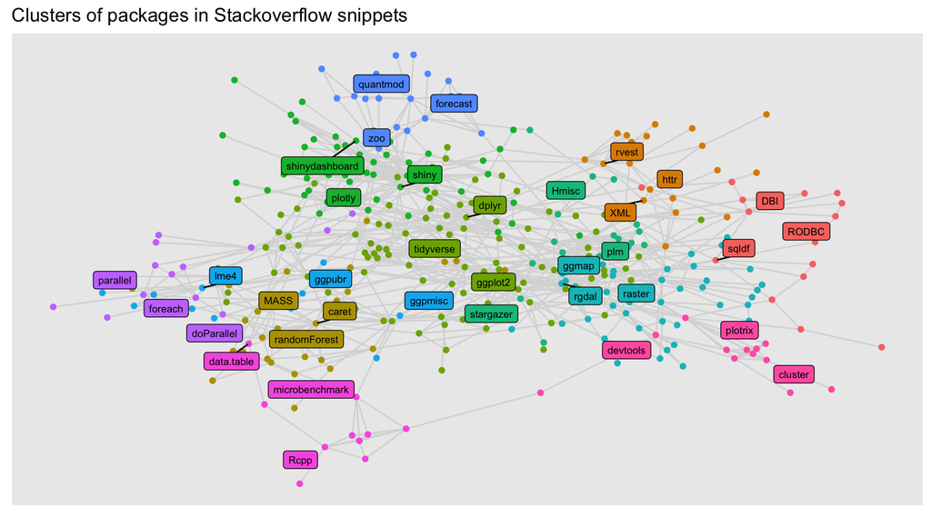

```r
ig <- igraph::graph_from_data_frame(sig_assocs, directed = FALSE)
ig <- tidygraph::as_tbl_graph(ig)

clust <- igraph::cluster_walktrap(ig)

# Add community data to the graph
ig <- ig |>
  activate(nodes) |>
  mutate(
    cluster = factor(membership(clust)),
    mentions = total_mentions[name]
  ) |>
  group_by(cluster) |>
  mutate(
    n_members = n()
  ) |>
  ungroup()


# We'll use this to label just a few packages in each cluster
top_3_per_cluster <- function (x)  {
  x |> group_by(cluster) |>
    arrange(desc(mentions)) |>
    slice_head(n = 3)
}


ig |>
  filter(n_members >= 10) |>
  ggraph(layout = "fr") +
    geom_edge_link(colour = "grey85", linewidth = 0.5) +
    geom_node_point(aes(colour = cluster)) +
    geom_node_label(aes(label = name, fill = cluster), size = 2.5,
                    data = top_3_per_cluster, repel = TRUE) +
    theme(legend.position = "none") +
    labs(
      title = "Clusters of packages in Stackoverflow snippets"
    )
```

Again, these results look intuitively sensible. We can see:

- a large tidyverse cluster;
- a time-series cluster with `{quantmod}` and `{zoo}` ;
- a spatial data cluster with `{rgdal}` , `{raster}` and `{ggmap}` ;
- a “make it go faster” cluster, maybe, with `{Rcpp}` , `{data.table}` and `{microbenchmark}` ;
- clusters for parallel processing, Shiny, web scraping and database access.

# Finding alternatives

Can we do more?

Suppose that some packages are *alternatives* to each other - they are often used for similar tasks, but rarely used together. Canonical examples might be `{dplyr}` and `{data.table}` , or `{sp}` and `{sf}` .

If so, we might expect those packages to be used with similar sets of other packages, but not to have a direct link between them. So you might see

```r
library(sf)
library(maptools)
```

or

```r
library(sp)
library(maptools)
```

but rarely

```r
library(sf)
library(sp)
```

Let’s look for such pairs of packages. We’ll join `sig_assocs` to itself, to get indirect associations between pairs of packages.

```r
sig_assocs_reversed <- sig_assocs |>
  select(pkg2, pkg1, p.value) |>
  rename(pkg1 = pkg2, pkg2 = pkg1)

sig_assocs_twice <- rbind(sig_assocs, sig_assocs_reversed) |>
  select(pkg1, pkg2) |>
  arrange(pkg1, pkg2)

# To capture all links, we have to go both ways through the graph
sig_indirect <- inner_join(sig_assocs_twice, sig_assocs_twice,
                          by = c("pkg2" = "pkg1"),
                          relationship = "many-to-many") |>
  select(-pkg2) |>
  rename(pkg2 = pkg2.y) |>
  # remove paths that loop back on themselves
  filter(pkg1 != pkg2)
```

Then we’ll remove any packages that have a *direct* link between them.

```r
alts <- sig_indirect |>
  anti_join(sig_assocs_twice, by = join_by(pkg1, pkg2)) |>
  add_count(pkg1, pkg2) |>
  distinct(pkg1, pkg2, .keep_all = TRUE)
```

Lastly, we’ll filter for packages with a minimum number of indirect paths between them, to avoid too many false positives.

```r
alts |>
  filter(n >= 3) |>
  select(Package = pkg1, Alternative = pkg2) |>
  DT::datatable(filter = "top", caption = "Alternative packages")
```

|  | Package | Alternative |
| --- | --- | --- |
| 1 | Biostrings | shinyjs |
| 2 | Biostrings | shiny |
| 3 | Biostrings | shinyWidgets |
| 4 | DiagrammeR | shinydashboard |
| 5 | DiagrammeRsvg | shinydashboard |
| 6 | Epi | plyr |
| 7 | PerformanceAnalytics | ROI |
| 8 | PerformanceAnalytics | forecast |
| 9 | PortfolioAnalytics | quantmod |
| 10 | Quandl | vars |

[output cut: 260 more lines]

Exploring the above, it seems to work *sometimes*. `{dplyr}` and `{data.table}` don’t show up – perhaps those packages just live in too different worlds. But pairs of packages like `{PerformanceAnalytics}` and `{ROI}` , or `{RCurl}` and `{rvest}` might be reasonable alternatives. Then again, is `{RColorBrewer}` really an alternative to `{rtweet}` ? Hmm…. We might do better with a subtler network analysis, but I’ll leave it here for now.

# Data

Here’s the list of communities.

|  | name | cluster | mentions | n_members | Other packages |
| --- | --- | --- | --- | --- | --- |
| 1 | DBI | 1 | 30 | 17 | DBI, RODBC, sqldf, sparklyr, RSQLite, ... |
| 2 | RODBC | 1 | 22 | 17 | DBI, RODBC, sqldf, sparklyr, RSQLite, ... |
| 3 | sqldf | 1 | 20 | 17 | DBI, RODBC, sqldf, sparklyr, RSQLite, ... |
| 4 | sparklyr | 1 | 18 | 17 | DBI, RODBC, sqldf, sparklyr, RSQLite, ... |
| 5 | RSQLite | 1 | 16 | 17 | DBI, RODBC, sqldf, sparklyr, RSQLite, ... |
| 6 | RMySQL | 1 | 14 | 17 | DBI, RODBC, sqldf, sparklyr, RSQLite, ... |
| 7 | odbc | 1 | 10 | 17 | DBI, RODBC, sqldf, sparklyr, RSQLite, ... |
| 8 | dbplyr | 1 | 9 | 17 | DBI, RODBC, sqldf, sparklyr, RSQLite, ... |
| 9 | pracma | 1 | 8 | 17 | DBI, RODBC, sqldf, sparklyr, RSQLite, ... |
| 10 | RJDBC | 1 | 8 | 17 | DBI, RODBC, sqldf, sparklyr, RSQLite, ... |

[output cut: 510 more lines]

Here’s the full list of associated packages:

|  | pkg1 | pkg2 |
| --- | --- | --- |
| 1 | AER | stargazer |
| 2 | AICcmodavg | car |
| 3 | AppliedPredictiveModeling | caret |
| 4 | AppliedPredictiveModeling | kernlab |
| 5 | Biostrings | bsplus |
| 6 | Biostrings | entropy |
| 7 | Biostrings | htmltools |
| 8 | Biostrings | readxl |
| 9 | Biostrings | shinyBS |
| 10 | Biostrings | shinycssloaders |

[output cut: 2202 more lines]

Or you can get the codesamples data from github and run [this script](https://hughjonesd.github.io/learning-from-codesamples.Rmd) yourself.